# UE BIO1540

David Martin

2024-09-01

# FICHE DE COURS n°2 : INTRODUCTION AUX TESTS STATISTIQUES (Partie 1)

L’objectif de ce second cours magistral est de reprendre les bases concernant les tests statistiques et d’être capable de mettre en place la **méthodologie** suivante pour une problématique donnée :

1. Visualiser les données.
2. Construire les hypothèses associées à la problématique.
3. Estimer les paramètres descriptivant la distribution de probabilité des variables. Donne-t’il une tendance pour répondre à la problématique ?
4. Choisir le test statistique qui vous aidera à prendre une décision.
5. Prendre une décision d’après la statistique du test et/ou sa p value ; l’estimation des paramètres peut aider à interpréter la décision.

## CHAPITRE 1 : Observation/Expérience/causalité

### Échantillons/populations

Une population comprend tous les individus ou objets d’intérêt. Les données sont collectées à partir d’un échantillon, qui est un sous-ensemble de la population.

*Exemple : pour estimer quel est le risque d’effet secondaire dans le traitement du cancer de la prostate par radio-thérapie, des chercheurs ont mené une étude sur une cohorte de plus de 300 patients. Pendant 5 ans après le traitement, ils ont surveillé la survenue d’effets secondaires. Ils ont trouvé que 35% de ces personnes ont souffert d’effets secondaires.*

Quelle est l’échantillon dans cette étude ?

Qu’est-ce qu’une population raisonnable à laquelle nous pourrions généraliser les conclusions de l’étude ? Vous pouvez lire le papier *The curse(s) of dimensionality* Naomi Altman and Martin Krzywinski (2018) Nat. Method, se trouvant dans votre espace cours pour comprendre les problématiques actuelles sur l’analyse des données en grande dimension.

> Pour rappel, l’**inférence statistique** est le processus d’utilisation des données d’un échantillon pour obtenir des informations sur la population. Exemple : “On infère sa moyenne.” Attention : le choix de l’échantillon peut-être biaisé et les conclusions de l’étude ne pourraient être généralisées à l’ensemble de la population.

### Données/Individu/variables

En statistique, les données issues d’un échantillon, sont rangées de telle sorte que :

- chaque ligne correspond à un(e) individu/observation.
- chaque colonne correspond à une variable.

Elles sont rangées dans un tableau que nous nommerons désormais une matrice $X_{ij}$ avec $i$ pour les individus/observations (lignes) et $j$ pour les variables (colonnes).

### Méthodologie d’analyse

La première étape lorsque vous réalisez une analyse est de décrire les données. Quels types de données ? Quels types de variables ? Comment peut-on représenter le problème biologique de manière visuel ?

Tout d’abord, retenez qu’il existe principalement deux types de variables :

- Les variables quantitatives (ex : un taux de cholesterol).
- Les variables qualitatives (ex : des stades de cancers).

La représentation visuelle et les statistiques associées seront totalement différentes. La visualisation dépendra du type de la variable à décrire et du problème associé. Pour chacune des problématiques que nous présenterons dans ce cours, il faudra déployer cette **méthodologie** :

1. Définir la(es) variable(s) à visualiser.
2. Définir un graphique permettant de visualiser le problème
3. Décrire numériquement les variables. Calculer des estimations pour synthétiser l’information observée ?
4. Poser les hypothèses statistiques.
5. Réaliser un test statistique pour valider ou refuser l’hypothèse nulle.
6. Conclure en restant objectif(ve) par rapport aux résultats.

## CHAPITRE 2 : Variables qualitatives

### Statistiques descriptives et visualisations

Dans le code ci joint, nous importons des données que nous stockons dans une table de type data.frame, concernant des sportifs de Haut niveau (SHN) et leur type de microbiote intestinaux. Dans cette étude les auteurs souhaitaient savoir si les SHN présentaient des microbiotes intestinaux différents de ceux des sujets Non-athlètes (NA).

Autrement dit la variable “SHN” présente si les individus (observations) sont des Sportifs de Haut Niveau (TRUE) ou non (FALSE, i.e. non athlètes). La variable “Type” prend deux valeurs soit 1 soit 2, qui définit le type de microbiote intestinal que possède l’individu. Brievement, les individus ayant un microbiote de type 1 possèdent des espèces bactériennes similaires et différents de ceux du type 2. Inversement pour les microbiote de type 2.

–> Quelles sont les types des variables ?

La première étape est de transformer la matrice en table de contingence (table à double entrée) où sont répertoriées des données de comptage entre deux variables qualitatives.

```r
df <- read.table("~/Dropbox/COURS/UBS/BIO1540/Package n°2/rawdata/SHN-microbiote.csv", sep=",", header=T, stringsAsFactors = T, encoding = 'latin1', row.names=1)
colnames(df)
```

```
## [1] "SHN"        "Enterotype"
```

```r
knitr::kable(table(df))
```

|  | 1 | 2 |
| --- | --- | --- |
| FALSE | 3 | 18 |
| TRUE | 18 | 11 |

**Questions**

1. Pouvons-nous utiliser ces données pour déterminer si le sport influence la composition du microbiote intestinal ?
2. Quelle est la population d’intérêt ?

> Cette question est l’une des plus importantes puisqu’elle conditionnera votre capacité à faire des conclusions à partir de votre analyse (**inférence statistique**).Il faut toujours se poser la question de comment a été echantillonné votre jeu de données et représente-t’il la population d’intérêt que vous souhaitez étudier. En statistique, on travaille souvent sur des échantillons. Dans ce cadre, on dira toujours qu’un paramètre (e.g. moyenne, variance, etc…) est estimé et on y ajoutera un chapeau. Ainsi, une probabilité estimée s’écrira $\hat{p}_{j}$ ou une moyenne s’écrira $\hat{\mu}_{j}$ pour une variable $j$.
3. Quelle est la proportion de SHN dans la population ($\hat{p}_{SHN}$) ? Proportion de SHN qui présente un microbiote de type 2 ($\hat{p}_{SHN|M=2}$) ? Proportion de NA (Non Athlètes) qui possède un microbiote de type 2 ($\hat{p}_{NA|M=2}$) ?
4. Trouver et interpréter $\hat{p}_{SHN}$ − $\hat{p}_{NA}$, la différence de proportion entre SHN et NA.

La proportion est une statistique qui aide à décrire la variable catégorielle pour ce groupe de jeunes hommes. Nous voyons que la proportion de SHN est égale à 58%. Une proportion (ou probabilité) se situera toujours entre 0 et 1 (ou bien 0 et 100%).

5. Comment peut-on représenter cette probabilité ? Utiliser la fonction pie(). *Vous avez toujours la possibilité d’aller de demander l’aide de R.*

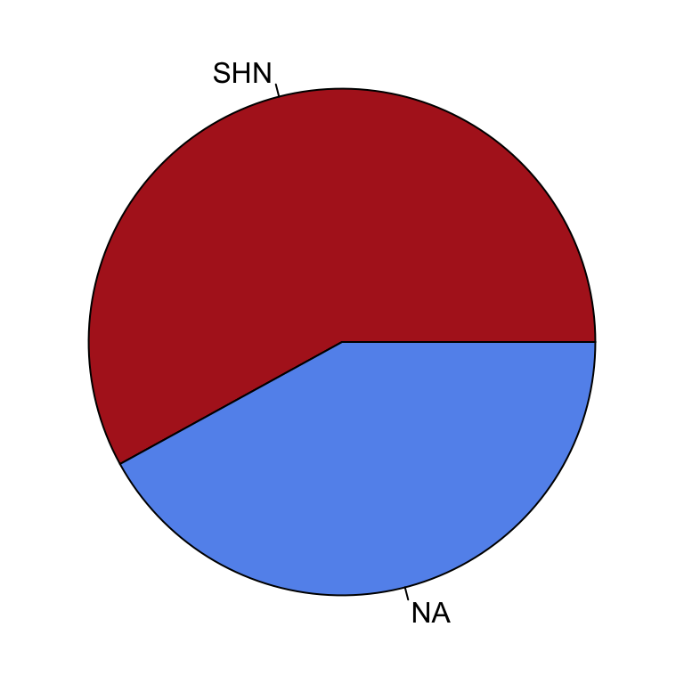

Figure 1 : Représentation en camembert des proportions de SHN vs NA au sein de l’échantillon étudié.

```r
SHN_NA <- c(sum(df$SHN==TRUE),sum(df$SHN==FALSE)) ## (1) Faire la somme des SHN et NA, peu importe le type de microbiote intestinal et (2) l'enregister dans un nouvel objet R.

par(mar=c(0,0,0,0)) # Permet de conditionner les marges du plot.
pie(SHN_NA, labels = c("SHN", "NA"), col=c("firebrick","cornflowerblue")) ## Utiliser la fonction pie.
```

Le **problème** sous jacent est donc le suivant : Est-ce que la proportion de SHN est la même dans le groupe des microbiote de type 1 que dans le groupe des microbiote de type 2 ? Cette question porte sur la relation entre les deux variables.

> ATTENTION : Assurez-vous de lire attentivement les questions lorsque vous utilisez une table à double entrée. Les questions ”Quelle proportion de SHN possède un microbiote de type 1 ? ” Et ” Quelle est la proportion de microbiote de type 1 parmi les SHN» semblent similaires mais posent des questions différentes.

Quel graphique pour repondre à la question du problème ? Que peut-on dire ? Peut-on conclure ? Causalité ?

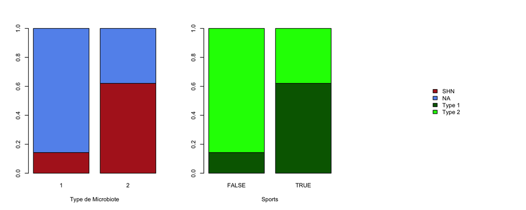

Figure 2 : (1) Représentation des proprotions de SHN/NA (rouge/bleue) en fonction du type de microbiote (2) Représentation des types de microbiote (vert foncé/vert clair) en fonction du niveau de sport.

```r
df.proportion.Sport <- apply(table(df), 2, function(x) {x/sum(x)}) # je calcul les proportions en ligne.
df.proportion.Microbiote <- apply(table(df), 1, function(x) {x/sum(x)}) # je calcul les proportions en colonne.

layout(matrix(c(1,2,3), nrow=1)) # permet de réaliser une fenêtre graphique à 3 cases
barplot(as.matrix(df.proportion.Sport), col=c("firebrick","cornflowerblue"), xlab="Type de Microbiote") # premier plot
barplot(as.matrix(df.proportion.Microbiote), col=c("darkgreen","green"), xlab="Sports")  # second plot

plot.new() # j'ajoute un troisième plot vide pour pouvoir placer la légende.
legend("center",c('SHN', 'NA', "Type 1", "Type 2"),
       fill=c("firebrick","cornflowerblue","darkgreen","green"), bty="n")
```

> Dans notre cas les deux graphiques ne sont pas différents de par la structure de notre table de contingence mais il pourrait l’être donc pensez à faire les deux graphiques/plot pour ne pas manquer les informations.

> RELATION NE VEUT PAS DIRE CAUSALITÉ.

### Tests Statistiques

#### Généralités

> Un test statistique (ou test d’hypothèses) utilise des données d’un échantillon pour décider entre deux hypothèses concernant une population en contrôlant le risque de se tromper.

Dans notre exemple où nous avons 2 variables qualitatives, nous souhaitons répondre à la question suivante : La proportion de SHN est la même dans les individus présentant un microbiote de type 1 que dans le groupe des individus présentant un microbiote de type 2.

Pour estimer la probabilité d’une dépendance entre deux variables qualitatives, vous pourrez utiliser le test du $\chi^2$. Son rôle est d’estimer et comparer la répartition des fréquences des modalités observées par rapport à une répartition théorique.

Cette répartition théorique dépend de la question de recherche posée. La valeur de $\chi^2$ identifie la probabilité que la répartition observée diffère de la répartition théorique **sous l’hypothèse nulle** , en fonction du nombre de degrés de liberté ($dl, k$).

**Hypothèse nulle $H_0$**, en pratique, on commence par étudier ce qui se passe sous l’hypothèse correspondant au cas où il n’y pas de différence. On pose $H_0$ qui se lit “Hypothèse nulle” où les deux variables sont indépendantes (ici, le fait d’être sportif est indépendant du type de microbiote **OU BIEN** le type de microbiote intestinal est indépendant du faite d’être sportif de haut niveau).

**Hypothèse alternative $H_1$** , dans l’hypothèse alternative, on indique que les variables sont dépendantes.

Hypothèse nulle ($H_0$) : Prétendre qu’il n’y a pas d’effet ou pas de dépendance.

Hypothèse alternative ($H_1$) : Revendication pour laquelle nous recherchons des preuves significatives.

L’hypothèse alternative est établie en observant les preuves (données) qui contredisent l’hypothèse nulle et soutiennent l’alternative hypothèse.

#### Erreurs liées à la prise de décision (p value)

On fait une erreur quand on se trompe de conclusion. Il y a 2 façons de se tromper :

- Lorsque que l’on rejette $H_0$ alors que $H_0$ vraie : Erreur de Type 1 (Faux positifs)
- Lorsque que l’on ne refuse pas $H_0$ alors que $H_0$ fausse : Erreur de Type 2. (Faux négatifs)

On sait estimer la probabilité de se tromper quand on rejette $H_0$ (i.e. p.value).

> A retenir, dans un test statistique, vous calculez deux paramètres : la statistique du test et la p value. Plus la p value tend vers 0 et plus le phénomène est rare sous $H_0$. Le degré de signification (ou p-value) nous donne un moyen formel de mesurer la “force” de la preuve qu’un échantillon fournit contre l’hypothèse nulle et à l’appui de l’hypothèse alternative. Autrement dit, **la p value nous informe sur le risque que l’on prend à rejetter $H_O$ à tort**.

Dans le cas du test du $\chi^2$, par exemple, plus le phénomène est rare sous $H_0$ et plus la dépendance entre deux variables qualitatives est importante.

### Test Statistique pour variables qualitatives ($\chi^2$)

Le test du $\chi^2$ va comparer les fréquences observées (O=observed) avec les fréquences attendues (E=expected) si H0 est correcte ou si nous choississons l’hypothèse alternative avec les taux d’erreurs associés.

Si nous repartons de notre tableau de contingence, nous avons observons les répartitions ci contre.

| Sports // type | 1 | 2 | **Total** |
| --- | --- | --- | --- |
| NA | 3 | 18 | 21 |
| SHN | 18 | 11 | 29 |
| **Total** | 21 | 29 | 50 |

**Question** Quels sont les probabilités attendues (Expected) **sous H0**? Nous observons que notre population se compose à 58% de SHN donc si les variables était totalement indépendantes on s’attendrait à avoir 58% de SHN dans chacun des types de microbiote intestinaux. On peut prendre le problème dans l’autre sens, nous observons 42% de microbiote de type 1, on devrait retrouver ce microbiote chez 42% des SHN et chez 42% de NA.

**Réponse** Etant donné que nous observons 21 microbiotes de type 1 (sur l’ensemble de notre échantillon) sur 50 individus, la probabilité $\hat{p}_{T1}$ est égale à 42% (ou 0.42), la théorie veut que 42% des SHN (0.42 x 29) et 42% des NA se trouvent dans la colonne 1 correspondant aux individus possédant un microbiote de type 1.

| Sports // Type | 1 | 2 |
| --- | --- | --- |
| NA | 21 x 0.42 = 8.82 | 21 x 0.58 = 12.18 |
| SHN | 29 x 0.42 = 12.18 | 29 x 0.58 = 16.82 |

**Question** Faites la même chose en faisant le raissonnement à partir du niveau de sports ?

Le calcul de la statistique se définit donc par l’écart entre la répartition observée et la répartition théorique soit :

$$\chi^2 = \sum_{j,k}
{\frac{(O_{j,k}-E_{j,k})^2}{E_{j,k}}}$$

```r
print(chisq.test(df$SHN, df$Enterotype))
```

```
##
##  Pearson's Chi-squared test with Yates' continuity correction
##
## data:  df$SHN and df$Enterotype
## X-squared = 9.5389, df = 1, p-value = 0.002012
```

> Il faut retenir que le test du $\chi^2$ se base sur la différence entre ce que l’on observe et ce que l’on devrait observer sous $H_0$.

**Conclusion** Que faut-il conclure ? Est-ce que la pratique du sport impacte le type de microbiote intestinal ? ou bien est-ce le type de microbiote intestinal qui permet de devenir un athlète de Haut Niveau ?

### Exercice

#### Pokemons

Refaire l’ensemble des analyses avec un jeu de données concernant les Pokemons provenant de https://www.data.gouv.fr/fr/datasets/jeu-de-donnees-sur-les-pokemons/. Je vous mets à disposition une table à double entrée où sont présentés deux variables : (1) Le pokémon possède 1 ou 2 types (Roche, Eau, Feu, Plantes, etc…) et (2) le pokémon possède une évolution (Oui ou Non).

| Evolution // nb de type | 1 type | 2 types |
| --- | --- | --- |
| Oui | 51 | 59 |
| Non | 64 | 41 |

1. Quelles sont les variables ?
2. Poser $H_0$ et $H_1$ ?
3. Réprésenter les résultats sous forme de graphique ?
4. Définir l’erreur de type 1 ?
5. Quelle conclusion ?